# EDS 213 API Lab

Wylie Hampson

10/6/2021

# Exercise 1

### Part 1

Read in the creek data.

```r
# Ventura River near Ventura, CA:
siteNumber <- "11118500"
parameterCd <- "00060" # Discharge
startDate <- "2019-10-01"
endDate <- "2020-10-05"

discharge_ventura <- readNWISdv(siteNumber, parameterCd, startDate, endDate) %>%
  renameNWISColumns()
```

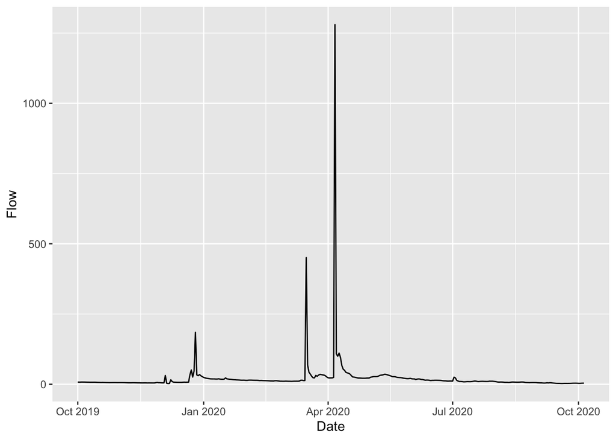

```r
statInfo <- attr(discharge_ventura, "statisticInfo")
variableInfo <- attr(discharge_ventura, "variableInfo")
siteInfo <- attr(discharge_ventura, "siteInfo")


ggplot(data = discharge_ventura, aes(x = Date, y = Flow)) +
  geom_line()
```

### Part 2: When did the data start

Same code without a start date.

```r
siteNumber <- "11118500"
parameterCd <- "00060" # Discharge
startDate <- ""
endDate <- "2020-10-05"

discharge_start <- readNWISdv(siteNumber, parameterCd, startDate, endDate) %>%
  renameNWISColumns()
```

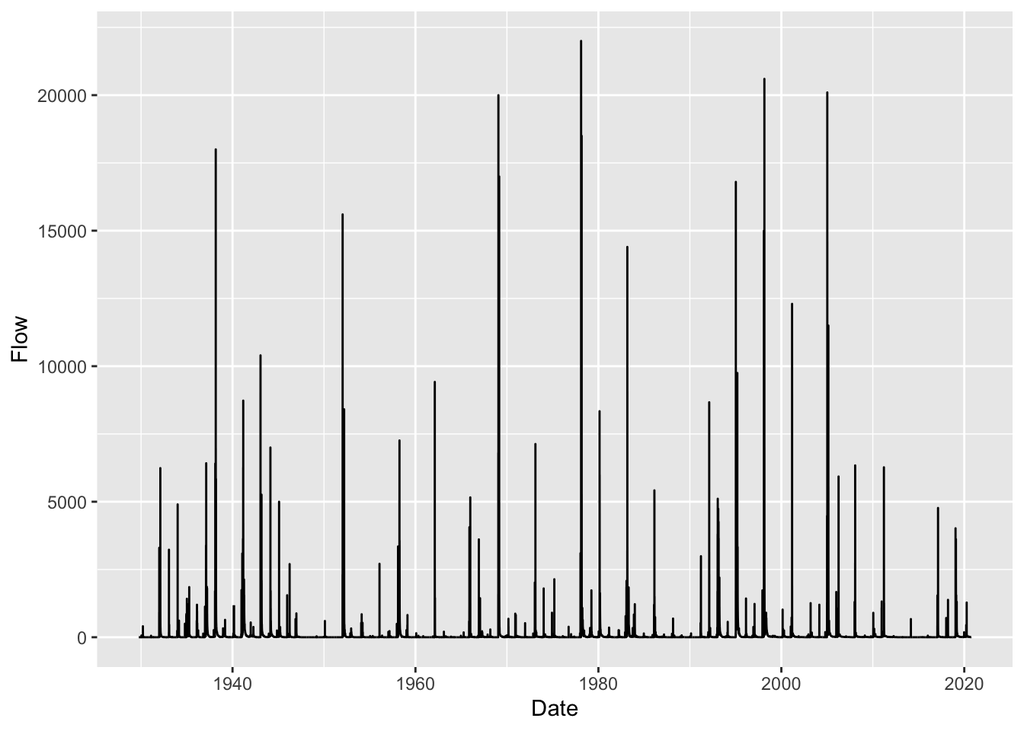

```r
statInfo_start <- attr(discharge_start, "statisticInfo")
variableInfo_start <- attr(discharge_start, "variableInfo")
siteInfo_start <- attr(discharge_start, "siteInfo")


ggplot(data = discharge_start, aes(x = Date, y = Flow)) +
  geom_line()
```

# Assignment 2.1

## Compare the Ventura river to the Santa Paula Creek.

We will want to pull in data to look at the rainfall that took place on Oct/04/2021.

### Read in the Santa Paula Creek data.

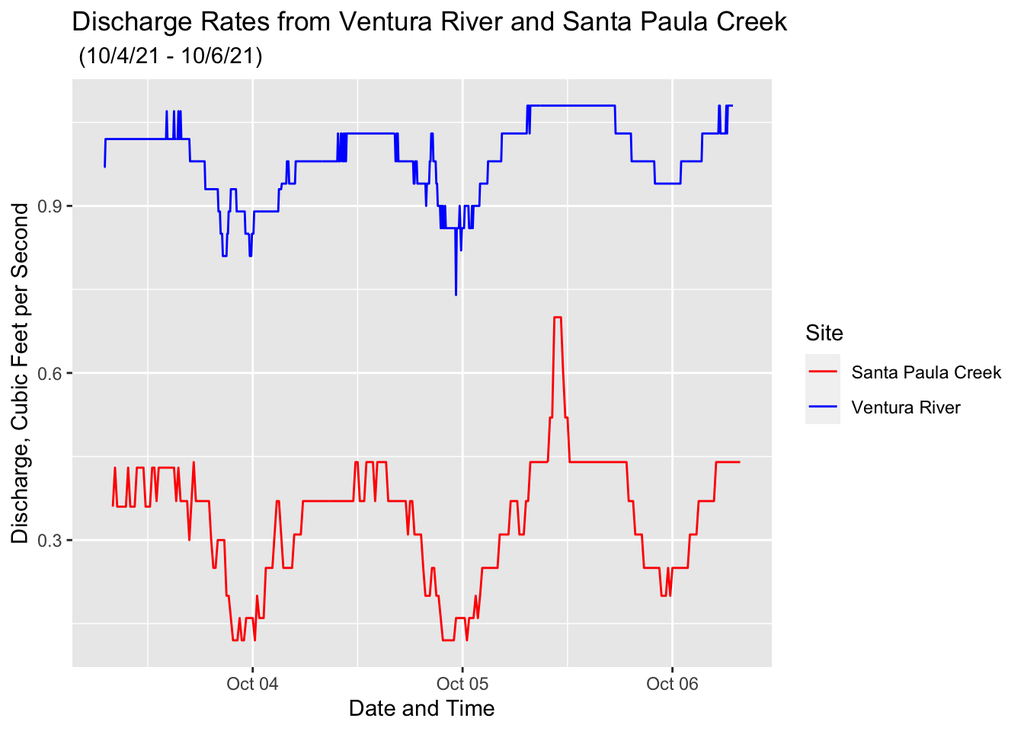

```r
# Query data for Ventura River (Site num. 11118500) and Santa Paula Creek (Site num. 11113500) into one data frame.
siteNumber_both <- c("11118500", "11113500")
parameterCd <- "00060" # Discharge
startDate <- "2021-10-03"
endDate <- "2021-10-05"

discharge_both <- readNWISuv(siteNumber_both, parameterCd, startDate, endDate) %>%
  renameNWISColumns()

# Now plot the data to compare the streamflow discharge of the two sites.
ggplot(data = discharge_both, aes(x = dateTime, y = Flow_Inst)) +
  geom_line(aes(col = site_no)) +
  labs(title = "Discharge Rates from Ventura River and Santa Paula Creek",
       subtitle = " (10/4/21 - 10/6/21)",
       x = "Date and Time",
       y = "Discharge, Cubic Feet per Second") +
  scale_color_manual(labels = c("Santa Paula Creek", "Ventura River"), values = c("red", "blue")) +
  guides(color = guide_legend("Site"))
```

(Assignment 2.1 question 3): Determine at what time did the stream flow peaked (if any) at the two locations? **The above plot shows the hourly flow rates for botht the Santa Paula Creek and the Ventura River. After the rain event that took place on Oct 4th, 2021, there was a peak in the stream flow discharge in the Santa Paula Creek just before 12 P.M. (noon) on October 5th, 2021. The Ventura River had a slight increase in overall discharge on Oct 5th, but not major peaks.**

# Exercise 2 (Assignment 2.2)

### Attcach metajam

```r
library(metajam)
```

### Download the data.

```r
data_obj <- "https://knb.ecoinformatics.org/knb/d1/mn/v2/object/urn%3Auuid%3A7fc6f6db-c5ea-426a-a743-1f2edafb43b8"
path <- here("data")

# Download the data
download_d1_data(data_obj, path)
```

```
##
## urn:uuid:7fc6f6db-c5ea-426a-a743-1f2edafb43b8
## is the latest version for identifier
## urn:uuid:7fc6f6db-c5ea-426a-a743-1f2edafb43b8
```

```
## Download metadata complete
```

[output not shown]

### Read in the data

```r
# Set the data path
data_path <- here("data", "doi_10.5063_F1CJ8BPH__household_language__csv")

# Read in the data
my_data <- read_d1_files(data_path)
# Get the household dataframe
hh_data <- my_data$data
```

### Find some statistics and plot it!

```r
# Find the percentage of Alaskan households that spoke only English
# Filter out only the data from 2009 to 2015
hh_data <- hh_data %>%
  filter(Year >= 2009)

# To find the percentage of households that speak only English, divide the speak_only_english data by the total data. First group by the year, and sum up the total households and English only households.

hh_data <- hh_data %>%
  group_by(Year) %>%
  summarize(total = sum(total), speak_only_english = sum(speak_only_english))

# Add a column to show the percentage of English only speaking households per year.
hh_data <- hh_data %>%
  mutate(english_only_percent = round(((speak_only_english / total) * 100), 2))

hh_data
```

```
## # A tibble: 7 × 4
##    Year  total speak_only_english english_only_percent
##   <dbl>  <dbl>              <dbl>                <dbl>
## 1  2009 628497             486498                 77.4
## 2  2010 674284             519063                 77.0
## 3  2011 681950             526487                 77.2
## 4  2012 692062             533640                 77.1
## 5  2013 700300             540154                 77.1
## 6  2014 708207             546498                 77.2
## 7  2015 712898             550398                 77.2
```

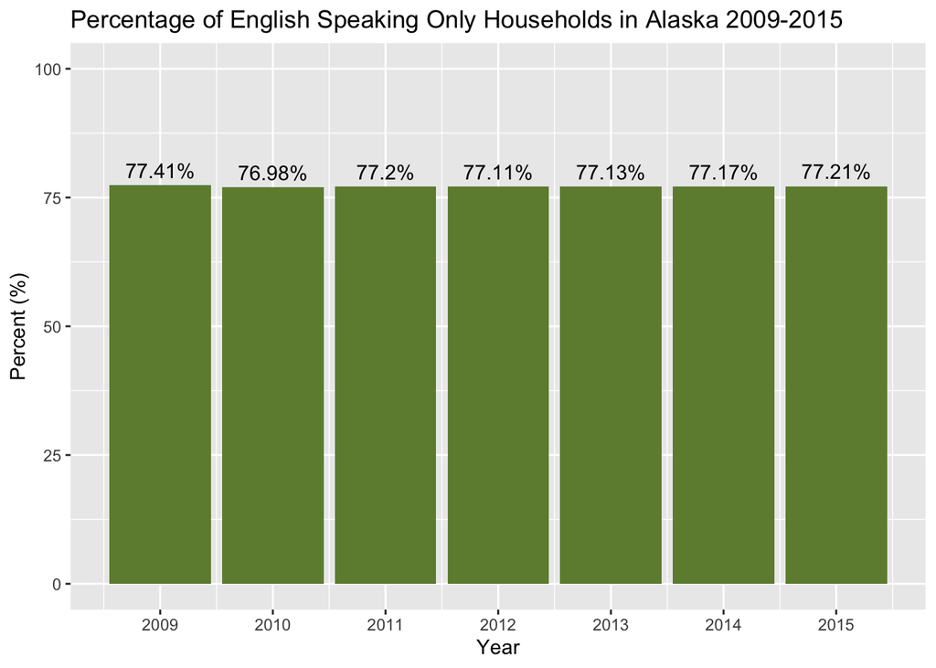

```r
# Now make a plot.
bar_percent <- ggplot(data = hh_data, aes(x = Year, y = english_only_percent)) +
  geom_bar(stat = "identity", fill = "darkolivegreen4") +
  geom_text(aes(label = paste0(english_only_percent, "%")), vjust = -0.5) +
  ylim(0, 100) +
  labs(title = "Percentage of English Speaking Only Households in Alaska 2009-2015",
       x = "Year",
       y = "Percent (%)") +
  scale_x_continuous(labels = as.character(hh_data$Year), breaks = hh_data$Year)

bar_percent
```

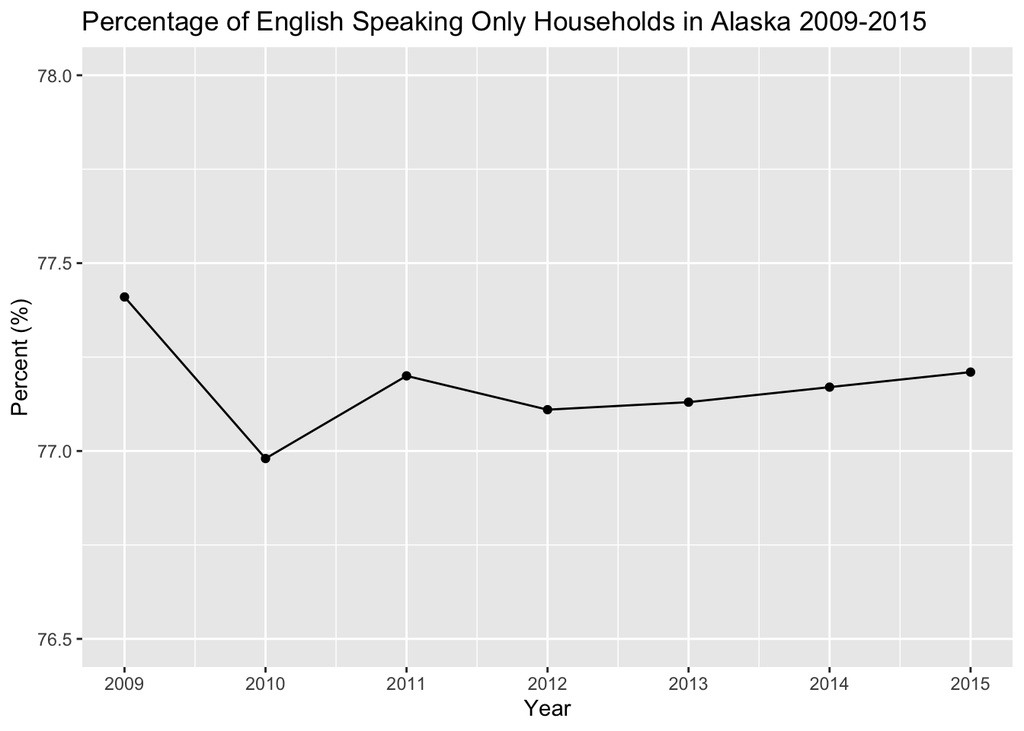

```r
# A line graph is a bit better for comparing the change from year to year since the overall change isn't very drastic.
line_percent <- ggplot(data = hh_data, aes(x = Year, y = english_only_percent)) +
  geom_line() +
  geom_point() +
  ylim(76.5, 78) +
  scale_x_continuous(labels = as.character(hh_data$Year), breaks = hh_data$Year) +
  labs(title = "Percentage of English Speaking Only Households in Alaska 2009-2015",
       x = "Year",
       y = "Percent (%)")

line_percent
```